# Problem Set 5: Calculus review

# 1. Derivatives

$1.$

$f(x)=3x^{4}-16x^{3}+18x^{2}$

$f'(x)=12x^{3}-48x^{2}+36x$

$2.$

$f(x)=\log(x^{2}+10) =\ln(x^{2}+10)$

$f'(x)=\frac{2x}{x^{2}+10}$

$3.$

$f(x)=\log_{10}(x^{2}\sin(x))$

$ = \frac{1}{\log(10)} \left(\frac{1}{x^{2}\sin(x)} \right) \left( x \cos(x + 2x\sin(x)) \right)$

$\displaystyle = \frac{2x \sin(x) + x^2 \cos(x)}{x^2 \sin(x)}$

$\displaystyle f'(x) = \frac{2 \sin(x) + x \cos(x)}{x \sin(x)}$

$4.$

$f(x)=xe^{-x}$

$f'(x)=e^x+(-xe^x)$

$5.$

$\displaystyle f(x) = \frac{1}{2 \sqrt{2\pi}} e^{(-\frac{1}{2})(\frac{x-5}{2})} $

$\displaystyle \frac{d}{dx} \left[ \frac{e^{-\frac{x-5}{4}}}{2^{\frac{3}{2}} \sqrt{\pi}} \right]$

$\displaystyle = \frac{1}{{2^{\frac{3}{2}}\sqrt{\pi}}} * \frac{d}{dx} \left[ {e^{-\frac{x-5}{4}}} \right]$

$\displaystyle = \frac{e^{-\frac{x-5}{4}} * (-\frac{1}{4}(\frac{d}{dx}[x] + \frac{d}{dx}[-5]))}{{2^{\frac{3}{2}}\sqrt{\pi}}} $

$\displaystyle f'(x) = \frac{-e^{-\frac{x-5}{4}}}{2^{\frac{7}{2}}*\sqrt{\pi}}$

# 2) Minima and Maxima

1. calculate the first derivative,
2. find the zeros of the derivative to find the minima and maxima,
3. plot the function and verify your computed minima and maxima by plotting them as points on the graph.

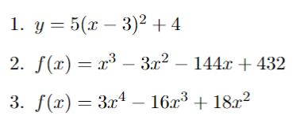

### 1. Find the first derivative

$ y = 5(x-3)^2 + 4\\ y = 5x^2 -30x + 49\\ y' = 10x - 30\\ y' = 10(x - 3)\\ $

$ y = x^3 - 3x^2 - 144x + 432\\ y' = 3x^2 - 6x - 144\\ $

$ y = 3x^4 - 16x^3 + 18x^2\\ y' = 12x^3 - 48x^2 + 36x\\ $

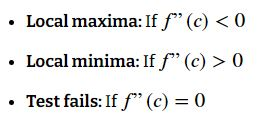

### 2. Find the zeros of the first derivative to find minima and maxima

### Finding zero point

$ \\ 0 = 10x - 30\\ 30 = 10x\\ x = 3\\ $

### Finding out if its a minima or maxima

$ f'' = 10 $ So, It is a minimum at x = 3

### Finding the zero points

$ 0 = 3x^2 - 6x - 144\\ 0 = 3(x^2 - 2x - 48)\\ x = \frac{-b +/- \sqrt{b^2 - 4ac}}{2a}\\ a = 3\\ b = -6\\ c = -144\\ x = 8\\ x = -6\\ $

### Finding out if its a minima or maxima

$ \\ f'' = 6x - 6\\ f''(8) = 42\\ f''(-6) = -42\\ $ There is a minimum at $f''(8)$ and there is a maximum at $f''(-6)$

### Finding zero points

$ 0 = 12x^3 - 48x^2 + 36x\\ 0 = x * (12x^2 - 18x + 36)\\ 0 = 6x * (2x^2 - 8x + 6)\\ x = \frac{-b +/- \sqrt{b^2 - 4ac}}{2a}\\ $

$ a = 2\\ b = -8\\ c = 6\\ x = 0 \\ x = 3\\ x = 1 $

### Finding out if its a minima or maxima

$ f'' = 36x^2 - 96x + 36\\ f''(0) = 36\\ f''(1) = -24\\ f''(3) = 72\\ $ There is a minima at $f''(0)$ and $f''(3)$ and there is a maxima at $f''(1)$

```python
import pandas as pd
import numpy as np
import matplotlib.pyplot as plt
```

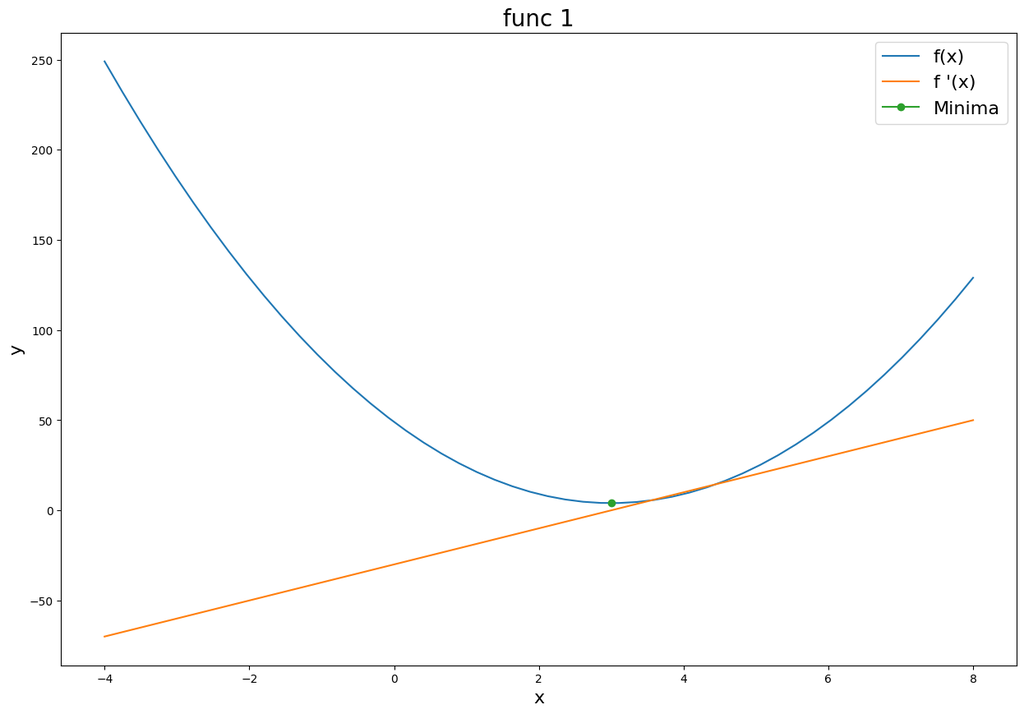

```python
# Helper function to make figures look better
def make_pretty(ax, title, x_label, y_label):
    ax.set_title(title, fontsize=20)
    ax.set_xlabel(x_label, fontsize=16)
    ax.set_ylabel(y_label, fontsize=16)
    ax.legend(loc='best', fontsize=16)
    return ax


fig, ax = plt.subplots(figsize=(15, 10))

x = np.linspace(-4, 8, )

func1_der = lambda x: 10*(x - 3)
func1 = lambda x: 5*x**2 -30*x + 49


ax.plot(x, func1(x), label='f(x)')
ax.plot(x, func1_der(x), label="f '(x)")
ax.plot(3, 4, marker='o', label='Minima')
make_pretty(ax, 'func 1', 'x', 'y')
```

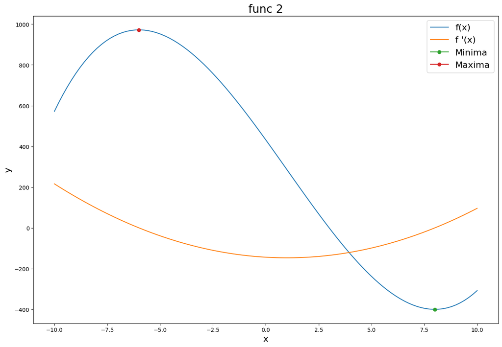

```python
fig, ax = plt.subplots(figsize=(15, 10))

x = np.linspace(-10, 10, 100)

func1_der = lambda x: 3*x**2 - 6*x - 144
func1 = lambda x: x**3 - 3*x**2 - 144*x + 432


ax.plot(x, func1(x), label='f(x)')
ax.plot(x, func1_der(x), label="f '(x)")
ax.plot(8, func1(8), marker='o', label='Minima')
ax.plot(-6, func1(-6), marker='o', label='Maxima')
make_pretty(ax, 'func 2', 'x', 'y')
```

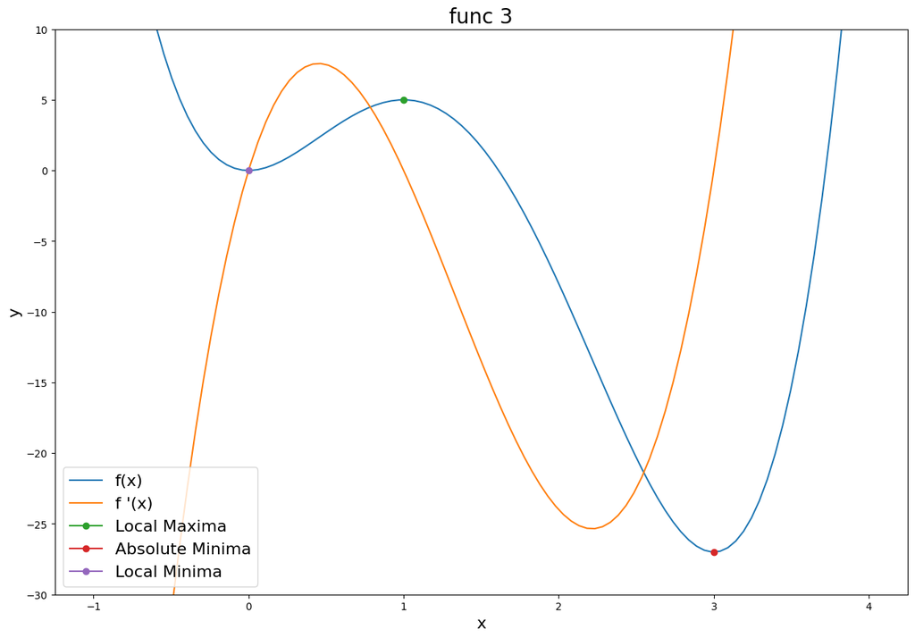

```python
fig, ax = plt.subplots(figsize=(15, 10))

x = np.linspace(-1, 4, 100)

func1_der = lambda x: 12*x**3 - 48*x**2 + 36*x
func1 = lambda x: 3*x**4 - 16*x**3 + 18*x**2


ax.plot(x, func1(x), label='f(x)')
ax.plot(x, func1_der(x), label="f '(x)")
ax.plot(1, func1(1), marker='o', label='Local Maxima')
ax.plot(3, func1(3), marker='o', label='Absolute Minima')
ax.plot(0, func1(0), marker='o', label='Local Minima')
plt.ylim(-30, 10)
make_pretty(ax, 'func 3', 'x', 'y')
```

# 3. Tangent Lines

Many optimization algorithms use a tangent line to approximate a curve at a given point. You will compute the tangent lines to the curve.

Steps:

1. Calculate the value $y1$ of the function $f (x)$ at $x_1$
2. Calculate the slope $m$ of the function at $x1$ using the first derivative $m = f ′(x1)$
3. Plug the point $(x_1, y_1)$ and slope m into the point-slope line equation $y = mx + b$  
   Use $y −y1 = m(x −x1)$ to solve for the equation of a line $y = mx + b$  
   For each of the points below, find the equations for the tangent lines for $f (x) = 5(x −3)^2$ + 4 and draw the tangent lines on a plot of f (x). Do you notice anything about the slopes as x gets farther away from the minima?

   $ x_1 = 0\\ x_2 = 1\\ x_3 = 3\\ x_4 = 5\\ $

### Calculate the value $y_1$ of the function $f(x)$ at $f(x_1)$

$ y_1 = 49\\ y_2 = 24\\ y_3 = 4\\ y_4 = 24\\ $

### Calculate the slope of the function at $x_1$ using the first derivative $m=f(x_1)$

First derivative: $ f'= 10x-30 $

Plugging in values:  
$ y_1 = -30\\ y_2 = -20\\ y_3 = 0\\ y_4 = 20\\ $

### Plug the points $(x_1, y_1)$ and slope $m$ into the point-slope line equation $y=mx + b$

$ y - mx = b\\ $

- $49 - -30 * 0 = b$
- $b = 49$
- $24 - -20 = b$
- $b = 44$
- $b = 4$
- $24 - 20*5 = b$
- $b = -76$

The slopes get more extreme the further away you get from the minima

Subtract the gradient to get to the extrema

# 4. Newthon's method

$ f' = 15(x - 3)^2\\ $ $ f'' = 30(x-3) $

```python
func = lambda x: 5*(x-3)**3 + 4
func_prime = lambda x: 15*(x-3)**2
func_double_prime = lambda x: 30*(x-3)

# Newton's method
def newtons_method(func, func_prime, x):
    stop = 10000
    points = [x]
    while stop > 0.001:
        current = x - (func(x) / func_prime(x))
        points.append(current)
        stop = abs(x - current)
        x = current
    return points


initial_guess = -5
points = newtons_method(func, func_prime, initial_guess)

y_changes = [func(point) for point in points]
```

```python
df_points = pd.DataFrame({
    'x': points,
    'y': [func(point) for point in points]
})

df_points.head(len(df_points))
```

|  | x | y |
| --- | --- | --- |
| 0 | -5.000000 | -2.556000e+03 |
| 1 | -2.337500 | -7.562977e+02 |
| 2 | -0.567694 | -2.230558e+02 |
| 3 | 0.600587 | -6.506929e+01 |
| 4 | 1.354072 | -1.829473e+01 |
| 5 | 1.804280 | -4.547871e+00 |
| 6 | 2.016340 | -7.588799e-01 |
| 7 | 2.068627 | -3.962379e-02 |
| 8 | 2.071672 | -1.294125e-04 |
| 9 | 2.071682 | -1.395586e-09 |

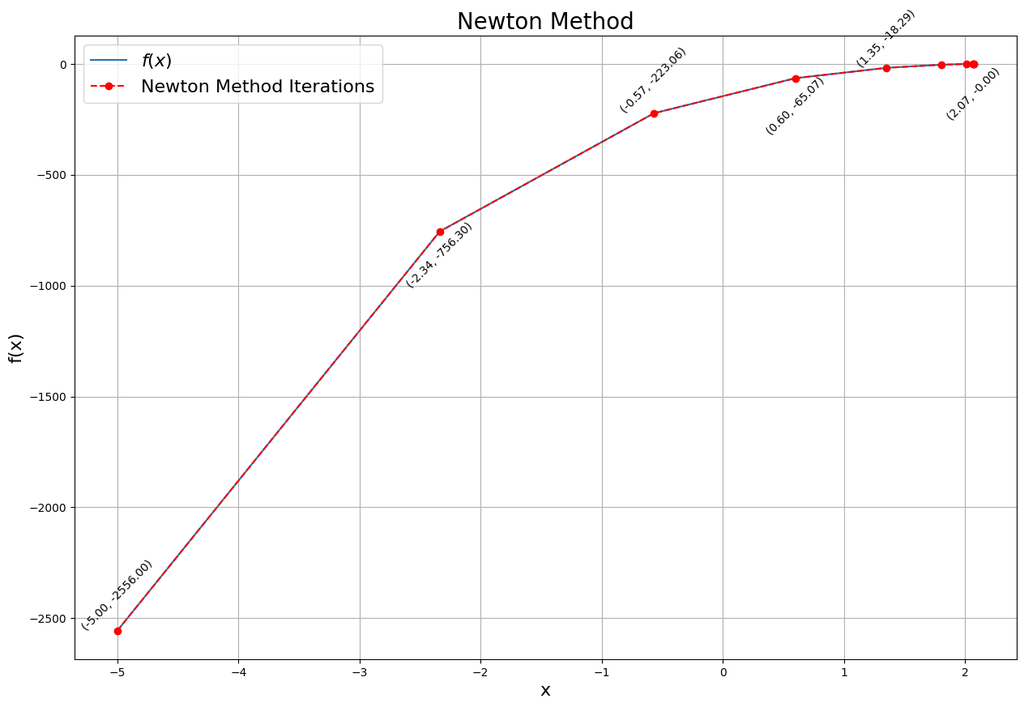

```python
fig, ax = plt.subplots(figsize=(15, 10))
x_values = np.linspace(-6, 10, 400)
ax.plot(df_points['x'], df_points['y'], label='$f(x)$')
ax.plot(points, y_changes, 'ro--', label='Newton Method Iterations')

# Annotate the first 5 points and the last point with alternating positions
for i, point in enumerate(points):
    if i < 5 or i == len(points) - 1:
        offset = 0 if i % 2 == 0 else -50
        ax.annotate(f'({point:.2f}, {y_changes[i]:.2f})', (point, y_changes[i]), textcoords="offset points", xytext=(0, offset), ha='center', rotation=45)


make_pretty(ax, 'Newton Method', 'x', 'f(x)')
ax.grid(True)
```

# 5. Gradients and partial derivatives

$$ f(x, y, z) = x^5 + 3x^2y^2 + 3xy^4 + z^2y^2 + 4xyz + z^2 $$

- $\frac{\partial f}{\partial x} = 5x^4 + 9xy^2 + 3y^4 + 4yz$
- $\frac{\partial f}{\partial y} = 6x^2y + 12xy^3 + 2yz^2 + 4xz$
- $\frac{\partial f}{\partial z} = 2y^2z + 4xy + 2z$
- $\delta f(v) = [\frac{\partial f}{\partial x}, \frac{\partial f}{\partial y}, \frac{\partial f}{\partial z}].T$

Notes:

$ log(ab) = log a + log b $

$ log(a/b) = log a - log b $

$ log(a^b) = b*log a $